# Tarea_09_solución

LMT

noviembre de 2021

El objetivo de la tarea es que resulevan ejemplos prácticos de manipulación de datos dado que es muy común que al trabajr con datos una parte importante del tiempo se lo lleva el preprocesamiento de los mismos.

```r
# Limpiar área de trabajo
rm(list = ls())
```

```r
# Cargar librerías
suppressMessages(library(tidyverse))
library(ggplot2)
library(readr)
library(stringr)

library(readxl)
library(haven)
```

**Ejercicio 1**

Utilizar los datos de sucursales para identificar los bancos que tienen presencia en municipios donde ningun otro banco tiene una sucursal, es decir, para cada banco identificar el número de municipios donde son los unicos que tienen alguna sucursal. Notar que habrá bancos que no cumplan con este criterio. Proporcionar una tabla con el nombre del banco y el número de municipios donde sólo ellos tienen sucursales.

```r
sucursales <- read_excel("~/Documentos/Acatlan/datos/sucursales/sucursales_por_municipio_202004.xlsx")
glimpse(sucursales)
```

```
## Rows: 4,329
## Columns: 8
## $ CVE_PERIODO      <dbl> 202004, 202004, 202004, 202004, 202004, 202004,…
## $ CVE_INSTITUCION  <chr> "040002", "040002", "040002", "040002", "040002…
## $ DESC_INSTITUCION <chr> "Banamex", "Banamex", "Banamex", "Banamex", "Ba…
## $ CVE_EDO          <chr> "01", "01", "02", "02", "02", "02", "03", "03",…
## $ DESC_EDO         <chr> "Aguascalientes", "Aguascalientes", "Baja Calif…
## $ DESC_MUN         <chr> "Aguascalientes", "Calvillo", "Ensenada", "Mexi…
## $ LLAVE            <chr> "Aguascalientes_Aguascalientes", "Aguascaliente…
## $ NUM_SUCURSALES   <dbl> 8, 1, 4, 5, 1, 8, 1, 2, 2, 1, 2, 1, 1, 1, 1, 1,…
```

Identificar que municipios tienen un único banco (pueden tener más de 1 sucursal)

```r
municipios_1_solo_banco <- sucursales %>%
                            group_by(LLAVE) %>%
                            summarise(num_bancos = n_distinct(CVE_INSTITUCION)) %>%
                            filter(num_bancos == 1) %>%
                            select(LLAVE) %>%
                            pull()
length(municipios_1_solo_banco)
```

```
## [1] 288
```

Utilizar los municipios obtenidos en el paso previo para conocer para cada banco el número de municipios donde tienen presesncia unica.

```r
tabla <- sucursales %>%
          filter(LLAVE %in% municipios_1_solo_banco) %>%
          group_by(CVE_INSTITUCION,DESC_INSTITUCION) %>%
          summarise(num_municipios = n_distinct(LLAVE)) %>%
          arrange(desc(num_municipios))
tabla
```

```
## # A tibble: 12 x 3
## # Groups:   CVE_INSTITUCION [12]
##    CVE_INSTITUCION DESC_INSTITUCION   num_municipios
##    <chr>           <chr>                       <int>
##  1 040127          Banco Azteca                  194
##  2 040012          BBVA Bancomer                  34
##  3 040072          Banorte                        18
##  4 040137          BanCoppel                      13
##  5 040021          HSBC                           12
##  6 040014          Santander                       4
##  7 040130          Compartamos                     4
##  8 040062          Afirme                          2
##  9 040131          Banco Ahorro Famsa              2
## 10 040147          Bankaool                        2
## 11 040149          Forjadores                      2
## 12 040044          Scotiabank                      1
```

**Ejercicio 2**

Utilizar los datos de [ratings de películas](https://github.com/leonardomarintellez/muestreo_2021/tree/master/datos/MovieLens) para calcular lo siguiente:

- Número de usuarios y número de películas
- Las 3 películas con mejor promedio y las 3 películas con peor promedio
- La película con el mayor número de calificaciones y cuantás son.
- El usuario que ha calificado un mayor número de películas y cuántas ha calificado.
- El número promedio de evaluaciones por película.

Para el siguiente punto intenten resolver la parte de identificar el año usando expresiones regulares (regular expressions).

- Calcular el número de películas por año

Noten que para resolver un par de puntos deben unir la información de las tablas *data* e *item*

```r
columnas_datos <- c('user_id','item_id','rating','timestamp')
datos <- read_delim("~/Documentos/Acatlan/datos/MOVIELENS/ml-100k/u.data", delim = "\t", col_names = columnas_datos)
glimpse(datos)
```

```
## Rows: 100,000
## Columns: 4
## $ user_id   <dbl> 196, 186, 22, 244, 166, 298, 115, 253, 305, 6, 62, 286…
## $ item_id   <dbl> 242, 302, 377, 51, 346, 474, 265, 465, 451, 86, 257, 1…
## $ rating    <dbl> 3, 3, 1, 2, 1, 4, 2, 5, 3, 3, 2, 5, 5, 3, 3, 3, 5, 2, …
## $ timestamp <dbl> 881250949, 891717742, 878887116, 880606923, 886397596,…
```

```r
columnas_movies <- c('item_id', 'title', 'release_date', 'video_release_date', 'imdb_url','unknown', 'Action', 'Adventure','Animation', 'Children\'s', 'Comedy', 'Crime', 'Documentary', 'Drama', 'Fantasy','Film-Noir', 'Horror', 'Musical', 'Mystery', 'Romance', 'Sci-Fi', 'Thriller', 'War', 'Western')

movies <- read_delim("~/Documentos/Acatlan/datos/MOVIELENS/ml-100k/u.item", delim = "|", col_names = columnas_movies)
glimpse(movies)
```

```
## Rows: 1,682
## Columns: 24
## $ item_id            <dbl> 1, 2, 3, 4, 5, 6, 7, 8, 9, 10, 11, 12, 13, 14…
## $ title              <chr> "Toy Story (1995)", "GoldenEye (1995)", "Four…
## $ release_date       <chr> "01-Jan-1995", "01-Jan-1995", "01-Jan-1995", …
## $ video_release_date <lgl> NA, NA, NA, NA, NA, NA, NA, NA, NA, NA, NA, N…
## $ imdb_url           <chr> "http://us.imdb.com/M/title-exact?Toy%20Story…
## $ unknown            <dbl> 0, 0, 0, 0, 0, 0, 0, 0, 0, 0, 0, 0, 0, 0, 0, …
## $ Action             <dbl> 0, 1, 0, 1, 0, 0, 0, 0, 0, 0, 0, 0, 0, 0, 0, …
## $ Adventure          <dbl> 0, 1, 0, 0, 0, 0, 0, 0, 0, 0, 0, 0, 0, 0, 0, …
## $ Animation          <dbl> 1, 0, 0, 0, 0, 0, 0, 0, 0, 0, 0, 0, 0, 0, 0, …
## $ `Children's`       <dbl> 1, 0, 0, 0, 0, 0, 0, 1, 0, 0, 0, 0, 0, 0, 0, …
## $ Comedy             <dbl> 1, 0, 0, 1, 0, 0, 0, 1, 0, 0, 0, 0, 1, 0, 0, …
## $ Crime              <dbl> 0, 0, 0, 0, 1, 0, 0, 0, 0, 0, 1, 1, 0, 0, 0, …
## $ Documentary        <dbl> 0, 0, 0, 0, 0, 0, 0, 0, 0, 0, 0, 0, 0, 0, 0, …
## $ Drama              <dbl> 0, 0, 0, 1, 1, 1, 1, 1, 1, 1, 0, 0, 0, 1, 1, …
## $ Fantasy            <dbl> 0, 0, 0, 0, 0, 0, 0, 0, 0, 0, 0, 0, 0, 0, 0, …
## $ `Film-Noir`        <dbl> 0, 0, 0, 0, 0, 0, 0, 0, 0, 0, 0, 0, 0, 0, 0, …
## $ Horror             <dbl> 0, 0, 0, 0, 0, 0, 0, 0, 0, 0, 0, 0, 0, 0, 0, …
## $ Musical            <dbl> 0, 0, 0, 0, 0, 0, 0, 0, 0, 0, 0, 0, 0, 0, 0, …
## $ Mystery            <dbl> 0, 0, 0, 0, 0, 0, 0, 0, 0, 0, 0, 0, 0, 0, 0, …
## $ Romance            <dbl> 0, 0, 0, 0, 0, 0, 0, 0, 0, 0, 0, 0, 0, 1, 0, …
## $ `Sci-Fi`           <dbl> 0, 0, 0, 0, 0, 0, 1, 0, 0, 0, 0, 0, 0, 0, 0, …
## $ Thriller           <dbl> 0, 1, 1, 0, 1, 0, 0, 0, 0, 0, 1, 1, 0, 0, 0, …
## $ War                <dbl> 0, 0, 0, 0, 0, 0, 0, 0, 0, 1, 0, 0, 0, 0, 0, …
## $ Western            <dbl> 0, 0, 0, 0, 0, 0, 0, 0, 0, 0, 0, 0, 0, 0, 0, …
```

```r
ctmovies <- movies %>% select('item_id','title')
head(ctmovies)
```

```
## # A tibble: 6 x 2
##   item_id title
##     <dbl> <chr>
## 1       1 Toy Story (1995)
## 2       2 GoldenEye (1995)
## 3       3 Four Rooms (1995)
## 4       4 Get Shorty (1995)
## 5       5 Copycat (1995)
## 6       6 Shanghai Triad (Yao a yao yao dao waipo qiao) (1995)
```

Unir las tablas

```r
movie_ratings <- left_join(datos,ctmovies, by = c("item_id"))
```

Top películas con mejor calificación

```r
movie_ratings %>% group_by(item_id, title) %>%
                  summarise(numero_calificaciones = n(), calificacion_promedio = mean(rating)) %>%
                  arrange(desc(calificacion_promedio)) %>%
                  head(20)
```

```
## # A tibble: 20 x 4
## # Groups:   item_id [20]
##    item_id title                      numero_calificaci… calificacion_prom…
##      <dbl> <chr>                                   <int>              <dbl>
##  1     814 "Great Day in Harlem, A (…                  1               5
##  2    1122 "They Made Me a Criminal …                  1               5
##  3    1189 "Prefontaine (1997)"                        3               5
##  4    1201 "Marlene Dietrich: Shadow…                  1               5
##  5    1293 "Star Kid (1997)"                           3               5
##  6    1467 "Saint of Fort Washington…                  2               5
##  7    1500 "Santa with Muscles (1996…                  2               5
##  8    1536 "Aiqing wansui (1994)"                      1               5
##  9    1599 "Someone Else's America (…                  1               5
## 10    1653 "Entertaining Angels: The…                  1               5
## 11    1449 "Pather Panchali (1955)"                    8               4.62
## 12     119 "Maya Lin: A Strong Clear…                  4               4.5
## 13    1398 "Anna (1996)"                               2               4.5
## 14    1594 "Everest (1998)"                            2               4.5
## 15    1642 "Some Mother's Son (1996)"                  2               4.5
## 16     408 "Close Shave, A (1995)"                   112               4.49
## 17     318 "Schindler's List (1993)"                 298               4.47
## 18     169 "Wrong Trousers, The (199…                118               4.47
## 19     483 "Casablanca (1942)"                       243               4.46
## 20     114 "Wallace & Gromit: The Be…                 67               4.45
```

Películas con peor calificación

```r
movie_ratings %>% group_by(item_id, title) %>%
                  summarise(numero_calificaciones = n(), calificacion_promedio = mean(rating)) %>%
                  arrange((calificacion_promedio)) %>%
                  head(20)
```

```
## # A tibble: 20 x 4
## # Groups:   item_id [20]
##    item_id title                      numero_calificaci… calificacion_prom…
##      <dbl> <chr>                                   <int>              <dbl>
##  1     314 3 Ninjas: High Noon At Me…                  5                  1
##  2     437 Amityville 1992: It's Abo…                  5                  1
##  3     439 Amityville: A New Generat…                  5                  1
##  4     599 Police Story 4: Project S…                  1                  1
##  5     784 Beyond Bedlam (1993)                        2                  1
##  6     830 Power 98 (1995)                             1                  1
##  7     852 Bloody Child, The (1996)                    1                  1
##  8     858 Amityville: Dollhouse (19…                  3                  1
##  9    1308 Babyfever (1994)                            2                  1
## 10    1309 Very Natural Thing, A (19…                  1                  1
## 11    1320 Homage (1995)                               1                  1
## 12    1325 August (1996)                               1                  1
## 13    1329 Low Life, The (1994)                        1                  1
## 14    1334 Somebody to Love (1994)                     2                  1
## 15    1339 Stefano Quantestorie (199…                  1                  1
## 16    1340 Crude Oasis, The (1995)                     1                  1
## 17    1341 Hedd Wyn (1992)                             1                  1
## 18    1343 Lotto Land (1995)                           1                  1
## 19    1348 Every Other Weekend (1990)                  1                  1
## 20    1349 Mille bolle blu (1993)                      1                  1
```

Película con el mayor número de calificaciones

```r
movie_ratings %>% group_by(item_id, title) %>%
                  summarise(numero_calificaciones = n(), calificacion_promedio = mean(rating)) %>%
                  arrange(desc(numero_calificaciones)) %>%
                  head(20)
```

```
## # A tibble: 20 x 4
## # Groups:   item_id [20]
##    item_id title                    numero_calificacio… calificacion_prome…
##      <dbl> <chr>                                  <int>               <dbl>
##  1      50 Star Wars (1977)                         583                4.36
##  2     258 Contact (1997)                           509                3.80
##  3     100 Fargo (1996)                             508                4.16
##  4     181 Return of the Jedi (198…                 507                4.01
##  5     294 Liar Liar (1997)                         485                3.16
##  6     286 English Patient, The (1…                 481                3.66
##  7     288 Scream (1996)                            478                3.44
##  8       1 Toy Story (1995)                         452                3.88
##  9     300 Air Force One (1997)                     431                3.63
## 10     121 Independence Day (ID4) …                 429                3.44
## 11     174 Raiders of the Lost Ark…                 420                4.25
## 12     127 Godfather, The (1972)                    413                4.28
## 13      56 Pulp Fiction (1994)                      394                4.06
## 14       7 Twelve Monkeys (1995)                    392                3.80
## 15      98 Silence of the Lambs, T…                 390                4.29
## 16     237 Jerry Maguire (1996)                     384                3.71
## 17     117 Rock, The (1996)                         378                3.69
## 18     172 Empire Strikes Back, Th…                 367                4.20
## 19     222 Star Trek: First Contac…                 365                3.66
## 20     204 Back to the Future (198…                 350                3.83
```

usuario que ha calificado mayor número de películas

```r
movie_ratings %>% group_by(user_id) %>%
                  summarise(numero_calificaciones = n(), calificacion_promedio = mean(rating)) %>%
                  arrange(desc(numero_calificaciones)) %>%
                  head(20)
```

```
## # A tibble: 20 x 3
##    user_id numero_calificaciones calificacion_promedio
##      <dbl>                 <int>                 <dbl>
##  1     405                   737                  1.83
##  2     655                   685                  2.91
##  3      13                   636                  3.10
##  4     450                   540                  3.86
##  5     276                   518                  3.47
##  6     416                   493                  3.85
##  7     537                   490                  2.87
##  8     303                   484                  3.37
##  9     234                   480                  3.12
## 10     393                   448                  3.34
## 11     181                   435                  1.49
## 12     279                   434                  3.27
## 13     429                   414                  3.39
## 14     846                   405                  3.74
## 15       7                   403                  3.97
## 16      94                   400                  3.66
## 17     682                   399                  3.14
## 18     308                   397                  3.76
## 19      92                   388                  3.24
## 20     293                   388                  3.03
```

Número promedio de evaluaciones por película

```r
movie_ratings %>% group_by(item_id, title) %>%
                  summarise(numero_calificaciones = n()) %>%
                  ungroup() %>%
                  summarise(promedio = mean(numero_calificaciones))
```

```
## # A tibble: 1 x 1
##   promedio
##      <dbl>
## 1     59.5
```

```r
movie_ratings %>% mutate(anio = str_extract(title, "\\d{4}")) %>%
head()
```

```
## # A tibble: 6 x 6
##   user_id item_id rating timestamp title                              anio
##     <dbl>   <dbl>  <dbl>     <dbl> <chr>                              <chr>
## 1     196     242      3 881250949 Kolya (1996)                       1996
## 2     186     302      3 891717742 L.A. Confidential (1997)           1997
## 3      22     377      1 878887116 Heavyweights (1994)                1994
## 4     244      51      2 880606923 Legends of the Fall (1994)         1994
## 5     166     346      1 886397596 Jackie Brown (1997)                1997
## 6     298     474      4 884182806 Dr. Strangelove or: How I Learned… 1963
```

```r
movie_ratings %>% mutate(anio = str_extract(title, "\\d+")) %>%
head()
```

```
## # A tibble: 6 x 6
##   user_id item_id rating timestamp title                              anio
##     <dbl>   <dbl>  <dbl>     <dbl> <chr>                              <chr>
## 1     196     242      3 881250949 Kolya (1996)                       1996
## 2     186     302      3 891717742 L.A. Confidential (1997)           1997
## 3      22     377      1 878887116 Heavyweights (1994)                1994
## 4     244      51      2 880606923 Legends of the Fall (1994)         1994
## 5     166     346      1 886397596 Jackie Brown (1997)                1997
## 6     298     474      4 884182806 Dr. Strangelove or: How I Learned… 1963
```

**Puntos a discutir**. Las encuestas voluntarias pueden incluir sesgos como son preferencias de unicamente los individuos.

**Ejercicio 3**

Utilizar los datos del [censo 2010](https://github.com/leonardomarintellez/muestreo_2021/tree/master/datos/censo_2010) de la tabla de personas del Estado de México para crear una grafica de dispersión de la edad de la persona vs la edad de su madre. Para identificar las variables que les ayudarán para este ejercicio consulten el diccionario del cuestionario ubicado en el mismo vínculo que los datos. No a todas las personass podrán asignarles la edad de su madre, sólo conserven los registros donde tengan dato tanto de la persona como de su madre.

```r
#personas <- read_sas("~/Documentos/Acatlan/datos/Censo_2010/MC2010_01_sas/personas_01.sas7bdat", NULL) %>%
#                select(ID_VIV,NUMPER,EDAD,IDMADRE)

personas <- read_sas("~/Documentos/Acatlan/datos/Censo_2010/MC2010_15_sas/personas_15a.sas7bdat", NULL) %>%
                select(ID_VIV,NUMPER,EDAD,IDMADRE)


glimpse(personas)
```

```
## Rows: 927,057
## Columns: 4
## $ ID_VIV  <chr> "00133080", "00133080", "00133080", "00133080", "0013308…
## $ NUMPER  <chr> "00002", "00004", "00001", "00003", "00005", "00001", "0…
## $ EDAD    <chr> "051", "014", "056", "017", "010", "075", "099", "019", …
## $ IDMADRE <chr> "", "02", "", "02", "02", "02", "", "02", "", "", "02", …
```

```r
tabla_edad_persona <- personas %>%
                      mutate(LLAVE =paste(ID_VIV,IDMADRE,sep = "_")) %>%  # La llave auxiluar es usar el id de la madre
                      rename(EDAD_PERSONA = EDAD) %>%
                      select(LLAVE, ID_VIV, NUMPER, EDAD_PERSONA)

head(tabla_edad_persona)
```

```
## # A tibble: 6 x 4
##   LLAVE       ID_VIV   NUMPER EDAD_PERSONA
##   <chr>       <chr>    <chr>  <chr>
## 1 00133080_   00133080 00002  051
## 2 00133080_02 00133080 00004  014
## 3 00133080_   00133080 00001  056
## 4 00133080_02 00133080 00003  017
## 5 00133080_02 00133080 00005  010
## 6 00163704_02 00163704 00001  075
```

```r
tabla_edad_madre <- personas %>%
                      mutate(LLAVE =paste(ID_VIV,substr(NUMPER,4,5),sep = "_")) %>%
                      rename(EDAD_MADRE = EDAD) %>%
                      select(LLAVE,ID_VIV, NUMPER, EDAD_MADRE)

head(tabla_edad_madre)
```

```
## # A tibble: 6 x 4
##   LLAVE       ID_VIV   NUMPER EDAD_MADRE
##   <chr>       <chr>    <chr>  <chr>
## 1 00133080_02 00133080 00002  051
## 2 00133080_04 00133080 00004  014
## 3 00133080_01 00133080 00001  056
## 4 00133080_03 00133080 00003  017
## 5 00133080_05 00133080 00005  010
## 6 00163704_01 00163704 00001  075
```

```r
tabla_union_info <- inner_join(tabla_edad_persona,tabla_edad_madre %>% select(-ID_VIV,-NUMPER), by =c("LLAVE"))
head(tabla_union_info)
```

```
## # A tibble: 6 x 5
##   LLAVE       ID_VIV   NUMPER EDAD_PERSONA EDAD_MADRE
##   <chr>       <chr>    <chr>  <chr>        <chr>
## 1 00133080_02 00133080 00004  014          051
## 2 00133080_02 00133080 00003  017          051
## 3 00133080_02 00133080 00005  010          051
## 4 00163704_02 00163704 00001  075          099
## 5 00095075_02 00095075 00003  019          043
## 6 00095075_02 00095075 00004  017          043
```

Número de registros que hicieron match

```r
glimpse(tabla_union_info)
```

```
## Rows: 452,220
## Columns: 5
## $ LLAVE        <chr> "00133080_02", "00133080_02", "00133080_02", "00163…
## $ ID_VIV       <chr> "00133080", "00133080", "00133080", "00163704", "00…
## $ NUMPER       <chr> "00004", "00003", "00005", "00001", "00003", "00004…
## $ EDAD_PERSONA <chr> "014", "017", "010", "075", "019", "017", "010", "0…
## $ EDAD_MADRE   <chr> "051", "051", "051", "099", "043", "043", "043", "0…
```

```r
tabla_union_info %>% filter(ID_VIV == "00133080")
```

```
## # A tibble: 3 x 5
##   LLAVE       ID_VIV   NUMPER EDAD_PERSONA EDAD_MADRE
##   <chr>       <chr>    <chr>  <chr>        <chr>
## 1 00133080_02 00133080 00004  014          051
## 2 00133080_02 00133080 00003  017          051
## 3 00133080_02 00133080 00005  010          051
```

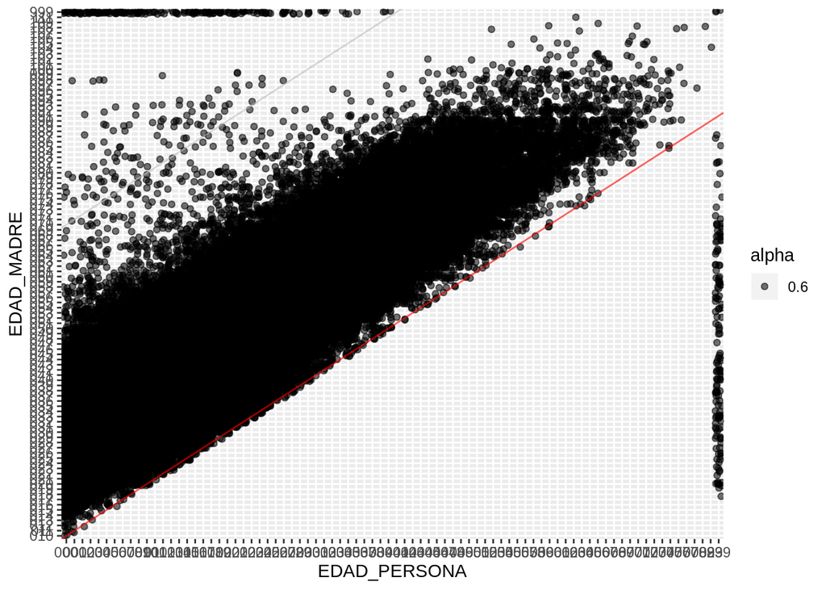

```r
ggplot(tabla_union_info) +
  geom_jitter(mapping = aes(x = EDAD_PERSONA, y = EDAD_MADRE, alpha = 0.6)) +
  geom_abline(intercept=0, slope=1, colour = "red", alpha = 0.6) +
  geom_abline(intercept = 60, slope = 1, colour = "grey", alpha = 0.6)
```

**Puntos a discutir**. Piede haber mala calidad en la información de las encuentas, tanto por el levantamiento como por la persona que responde

**Ejercicio 4**

Utilizar los datos que hemos visto en clase de [House Prices](https://github.com/leonardomarintellez/muestreo_2021/tree/master/datos/HousePrices). A esa tabla de datos deben crearle una variable adicional que tenga 2 categorías ‘train’ y ‘test’. El 70% de los registros deben estar arcados con la categoría ‘train’ y el restante 30% con la categoría ‘test’. Es decir, creen una muestra aleatoria de aproximadamente el 70% de los datos y a los ids que correspondan a los ids de la muestra asignenles la categoría ‘train’ y a los ids restantes asignenles la categoría ‘test’. En su mail de entrega de tarea adjuntar una tabla con 2 variables, el id de la casa y la categoría.

```r
precios <- read_csv("/home/leonardo/Documentos/Acatlan/datos/HousePrices/HousePrices.csv") %>% select(Id,SalePrice)
glimpse(precios)
```

```
## Rows: 1,460
## Columns: 2
## $ Id        <dbl> 1, 2, 3, 4, 5, 6, 7, 8, 9, 10, 11, 12, 13, 14, 15, 16,…
## $ SalePrice <dbl> 208500, 181500, 223500, 140000, 250000, 143000, 307000…
```

Tomar una muestra del 70% y asignarle la categoría train y al restante 30%

```r
n <- round(dim(precios)[1] * 0.70)
set.seed(1234)
ids_train <- precios %>% select(Id) %>% pull() %>% sample(n)

muestra_precios <- precios %>%
                  mutate(tipo = ifelse(Id %in% ids_train,"train","test"))
```

```r
head(muestra_precios)
```

```
## # A tibble: 6 x 3
##      Id SalePrice tipo
##   <dbl>     <dbl> <chr>
## 1     1    208500 test
## 2     2    181500 test
## 3     3    223500 train
## 4     4    140000 train
## 5     5    250000 test
## 6     6    143000 train
```

Comprobar la proporción

```r
muestra_precios %>%
  group_by(tipo) %>%
  summarise(n = n()) %>%
  mutate(prop = n / sum(n))
```

```
## # A tibble: 2 x 3
##   tipo      n  prop
##   <chr> <int> <dbl>
## 1 test    438   0.3
## 2 train  1022   0.7
```